# Análisis Exploratorio — IBM HR Analytics Employee Attrition

Felipe Obregón Ochoa | Psicólogo

2026-05-31

# 1. Carga de librerías

```r
library(tidyverse)  # manipulación y visualización de datos
library(naniar)     # visualización de valores faltantes
library(corrplot)   # matriz de correlaciones
library(GGally)     # correlaciones con ggplot2
```

# 2. Carga de datos

```r
# Cargar el CSV desde la carpeta data/
df <- readr::read_csv("../data/WA_Fn-UseC_-HR-Employee-Attrition.csv")

# Vista rápida de la estructura
glimpse(df)
```

```
## Rows: 1,470
## Columns: 35
## $ Age                      <dbl> 41, 49, 37, 33, 27, 32, 59, 30, 38, 36, 35, 2…
## $ Attrition                <chr> "Yes", "No", "Yes", "No", "No", "No", "No", "…
## $ BusinessTravel           <chr> "Travel_Rarely", "Travel_Frequently", "Travel…
## $ DailyRate                <dbl> 1102, 279, 1373, 1392, 591, 1005, 1324, 1358,…
## $ Department               <chr> "Sales", "Research & Development", "Research …
## $ DistanceFromHome         <dbl> 1, 8, 2, 3, 2, 2, 3, 24, 23, 27, 16, 15, 26, …
## $ Education                <dbl> 2, 1, 2, 4, 1, 2, 3, 1, 3, 3, 3, 2, 1, 2, 3, …
## $ EducationField           <chr> "Life Sciences", "Life Sciences", "Other", "L…
## $ EmployeeCount            <dbl> 1, 1, 1, 1, 1, 1, 1, 1, 1, 1, 1, 1, 1, 1, 1, …
## $ EmployeeNumber           <dbl> 1, 2, 4, 5, 7, 8, 10, 11, 12, 13, 14, 15, 16,…
## $ EnvironmentSatisfaction  <dbl> 2, 3, 4, 4, 1, 4, 3, 4, 4, 3, 1, 4, 1, 2, 3, …
## $ Gender                   <chr> "Female", "Male", "Male", "Female", "Male", "…
## $ HourlyRate               <dbl> 94, 61, 92, 56, 40, 79, 81, 67, 44, 94, 84, 4…
```

[output cut: 22 more lines]

# 3. Inspección inicial

```r
# Dimensiones del dataset
cat("Filas:", nrow(df), "\n")
```

```
## Filas: 1470
```

```r
cat("Columnas:", ncol(df), "\n")
```

```
## Columnas: 35
```

```r
# Nombres de columnas
names(df)
```

```
##  [1] "Age"                      "Attrition"
##  [3] "BusinessTravel"           "DailyRate"
##  [5] "Department"               "DistanceFromHome"
##  [7] "Education"                "EducationField"
##  [9] "EmployeeCount"            "EmployeeNumber"
## [11] "EnvironmentSatisfaction"  "Gender"
## [13] "HourlyRate"               "JobInvolvement"
## [15] "JobLevel"                 "JobRole"
## [17] "JobSatisfaction"          "MaritalStatus"
## [19] "MonthlyIncome"            "MonthlyRate"
## [21] "NumCompaniesWorked"       "Over18"
## [23] "OverTime"                 "PercentSalaryHike"
## [25] "PerformanceRating"        "RelationshipSatisfaction"
## [27] "StandardHours"            "StockOptionLevel"
## [29] "TotalWorkingYears"        "TrainingTimesLastYear"
## [31] "WorkLifeBalance"          "YearsAtCompany"
## [33] "YearsInCurrentRole"       "YearsSinceLastPromotion"
## [35] "YearsWithCurrManager"
```

```r
# Resumen estadístico general
summary(df)
```

```
##       Age         Attrition         BusinessTravel       DailyRate
##  Min.   :18.00   Length:1470        Length:1470        Min.   : 102.0
##  1st Qu.:30.00   Class :character   Class :character   1st Qu.: 465.0
##  Median :36.00   Mode  :character   Mode  :character   Median : 802.0
##  Mean   :36.92                                         Mean   : 802.5
##  3rd Qu.:43.00                                         3rd Qu.:1157.0
##  Max.   :60.00                                         Max.   :1499.0
##   Department        DistanceFromHome   Education     EducationField
##  Length:1470        Min.   : 1.000   Min.   :1.000   Length:1470
##  Class :character   1st Qu.: 2.000   1st Qu.:2.000   Class :character
##  Mode  :character   Median : 7.000   Median :3.000   Mode  :character
##                     Mean   : 9.193   Mean   :2.913
##                     3rd Qu.:14.000   3rd Qu.:4.000
##                     Max.   :29.000   Max.   :5.000
##  EmployeeCount EmployeeNumber   EnvironmentSatisfaction    Gender
##  Min.   :1     Min.   :   1.0   Min.   :1.000           Length:1470
##  1st Qu.:1     1st Qu.: 491.2   1st Qu.:2.000           Class :character
##  Median :1     Median :1020.5   Median :3.000           Mode  :character
##  Mean   :1     Mean   :1024.9   Mean   :2.722
##  3rd Qu.:1     3rd Qu.:1555.8   3rd Qu.:4.000
##  Max.   :1     Max.   :2068.0   Max.   :4.000
##    HourlyRate     JobInvolvement    JobLevel       JobRole
##  Min.   : 30.00   Min.   :1.00   Min.   :1.000   Length:1470
##  1st Qu.: 48.00   1st Qu.:2.00   1st Qu.:1.000   Class :character
##  Median : 66.00   Median :3.00   Median :2.000   Mode  :character
##  Mean   : 65.89   Mean   :2.73   Mean   :2.064
##  3rd Qu.: 83.75   3rd Qu.:3.00   3rd Qu.:3.000
##  Max.   :100.00   Max.   :4.00   Max.   :5.000
##  JobSatisfaction MaritalStatus      MonthlyIncome    MonthlyRate
##  Min.   :1.000   Length:1470        Min.   : 1009   Min.   : 2094
##  1st Qu.:2.000   Class :character   1st Qu.: 2911   1st Qu.: 8047
##  Median :3.000   Mode  :character   Median : 4919   Median :14236
##  Mean   :2.729                      Mean   : 6503   Mean   :14313
##  3rd Qu.:4.000                      3rd Qu.: 8379   3rd Qu.:20462
##  Max.   :4.000                      Max.   :19999   Max.   :26999
##  NumCompaniesWorked    Over18            OverTime         PercentSalaryHike
##  Min.   :0.000      Length:1470        Length:1470        Min.   :11.00
##  1st Qu.:1.000      Class :character   Class :character   1st Qu.:12.00
##  Median :2.000      Mode  :character   Mode  :character   Median :14.00
##  Mean   :2.693                                            Mean   :15.21
```

[output cut: 8 more lines]

```
##  Max.   :4.000     Max.   :4.000            Max.   :80    Max.   :3.0000
##  TotalWorkingYears TrainingTimesLastYear WorkLifeBalance YearsAtCompany
##  Min.   : 0.00     Min.   :0.000         Min.   :1.000   Min.   : 0.000
##  1st Qu.: 6.00     1st Qu.:2.000         1st Qu.:2.000   1st Qu.: 3.000
##  Median :10.00     Median :3.000         Median :3.000   Median : 5.000
##  Mean   :11.28     Mean   :2.799         Mean   :2.761   Mean   : 7.008
##  3rd Qu.:15.00     3rd Qu.:3.000         3rd Qu.:3.000   3rd Qu.: 9.000
##  Max.   :40.00     Max.   :6.000         Max.   :4.000   Max.   :40.000
##  YearsInCurrentRole YearsSinceLastPromotion YearsWithCurrManager
##  Min.   : 0.000     Min.   : 0.000          Min.   : 0.000
##  1st Qu.: 2.000     1st Qu.: 0.000          1st Qu.: 2.000
##  Median : 3.000     Median : 1.000          Median : 3.000
##  Mean   : 4.229     Mean   : 2.188          Mean   : 4.123
##  3rd Qu.: 7.000     3rd Qu.: 3.000          3rd Qu.: 7.000
##  Max.   :18.000     Max.   :15.000          Max.   :17.000
```

```r
# Identificar columnas sin variación (no aportan al análisis)
# En este dataset: EmployeeCount, Over18, StandardHours son constantes
df %>%
  select(EmployeeCount, Over18, StandardHours) %>%
  distinct()
```

```
## # A tibble: 1 × 3
##   EmployeeCount Over18 StandardHours
##           <dbl> <chr>          <dbl>
## 1             1 Y                 80
```

```r
# Eliminar columnas constantes y el ID (no aportan información)
df <- df %>%
  select(-EmployeeCount, -Over18, -StandardHours, -EmployeeNumber)

cat("Dataset limpio:", nrow(df), "filas y", ncol(df), "columnas\n")
```

```
## Dataset limpio: 1470 filas y 31 columnas
```

# 4. Valores faltantes

```r
# Conteo de NA por columna
na_conteo <- df %>%
  summarise(across(everything(), ~ sum(is.na(.)))) %>%
  pivot_longer(everything(), names_to = "variable", values_to = "na_count") %>%
  filter(na_count > 0)

if (nrow(na_conteo) == 0) {
  cat(" No hay valores faltantes en el dataset. Todas las variables están completas.\n")
  cat(" Total de celdas revisadas:", nrow(df) * ncol(df), "\n")
} else {
  # Si hubiera NAs, mostrar gráfico de barras horizontal
  ggplot(na_conteo, aes(x = reorder(variable, na_count), y = na_count)) +
    geom_col(fill = "#FF9800") +
    coord_flip() +
    theme_minimal() +
    labs(title = "Variables con valores faltantes",
         x = NULL, y = "Cantidad de NA")
}
```

```
##  No hay valores faltantes en el dataset. Todas las variables están completas.
##  Total de celdas revisadas: 45570
```

# 5. Variable objetivo: Attrition

```r
# Frecuencia absoluta y relativa
tabla_attrition <- df %>%
  count(Attrition) %>%
  mutate(
    porcentaje    = n / sum(n) * 100,
    etiqueta      = paste0(round(porcentaje, 1), "%")
  )

print(tabla_attrition)
```

```
## # A tibble: 2 × 4
##   Attrition     n porcentaje etiqueta
##   <chr>     <int>      <dbl> <chr>
## 1 No         1233       83.9 83.9%
## 2 Yes         237       16.1 16.1%
```

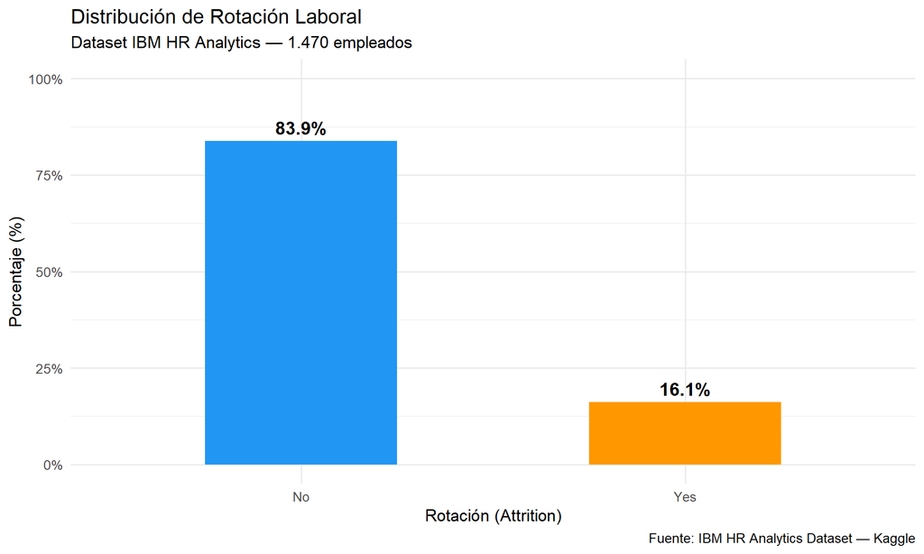

```r
# Gráfico de barras con porcentaje
ggplot(tabla_attrition, aes(x = Attrition, y = porcentaje, fill = Attrition)) +
  geom_col(width = 0.5, show.legend = FALSE) +
  geom_text(aes(label = etiqueta), vjust = -0.5, size = 5, fontface = "bold") +
  scale_fill_manual(values = c("No" = "#2196F3", "Yes" = "#FF9800")) +
  scale_y_continuous(limits = c(0, 100), labels = scales::percent_format(scale = 1)) +
  theme_minimal(base_size = 13) +
  labs(
    title    = "Distribución de Rotación Laboral",
    subtitle = "Dataset IBM HR Analytics — 1.470 empleados",
    x        = "Rotación (Attrition)",
    y        = "Porcentaje (%)",
    caption  = "Fuente: IBM HR Analytics Dataset — Kaggle"
  )
```

# 6. Análisis univariado — Variables numéricas

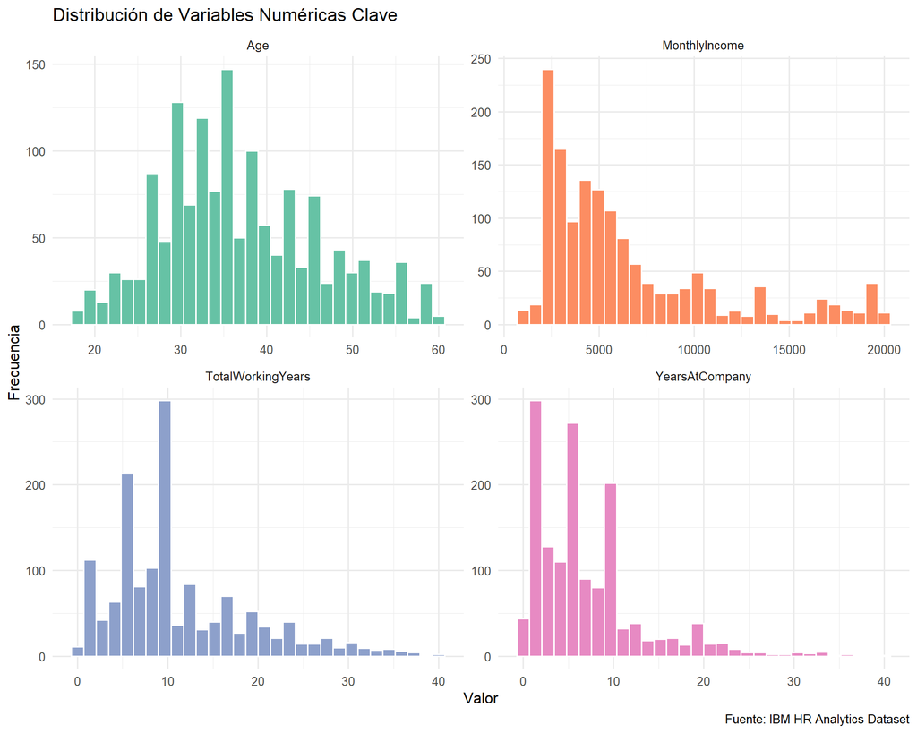

```r
# Variables numéricas clave para RRHH
vars_numericas <- df %>%
  select(Age, MonthlyIncome, YearsAtCompany, TotalWorkingYears)

# Histogramas
vars_numericas %>%
  pivot_longer(everything(), names_to = "variable", values_to = "valor") %>%
  ggplot(aes(x = valor, fill = variable)) +
  geom_histogram(bins = 30, color = "white", show.legend = FALSE) +
  facet_wrap(~ variable, scales = "free", ncol = 2) +
  scale_fill_brewer(palette = "Set2") +
  theme_minimal(base_size = 12) +
  labs(
    title   = "Distribución de Variables Numéricas Clave",
    x       = "Valor",
    y       = "Frecuencia",
    caption = "Fuente: IBM HR Analytics Dataset"
  )
```

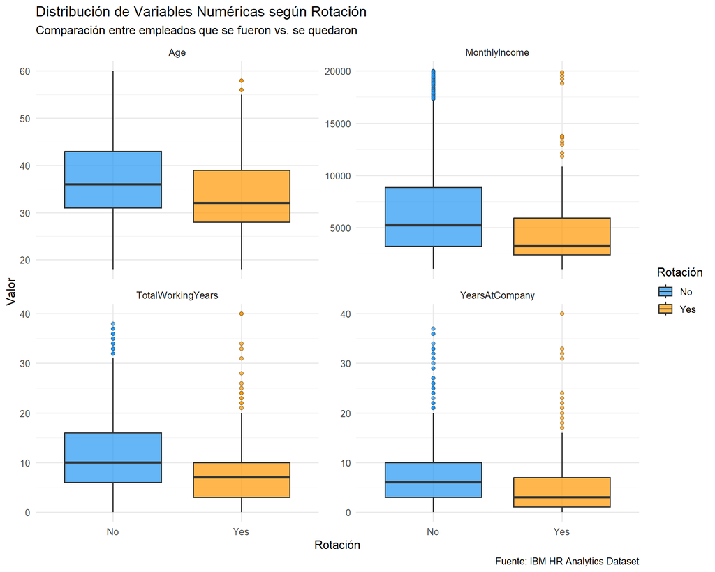

```r
# Boxplots comparando distribución según Attrition
df %>%
  select(Attrition, Age, MonthlyIncome, YearsAtCompany, TotalWorkingYears) %>%
  pivot_longer(-Attrition, names_to = "variable", values_to = "valor") %>%
  ggplot(aes(x = Attrition, y = valor, fill = Attrition)) +
  geom_boxplot(alpha = 0.7, outlier.shape = 21) +
  facet_wrap(~ variable, scales = "free_y", ncol = 2) +
  scale_fill_manual(values = c("No" = "#2196F3", "Yes" = "#FF9800")) +
  theme_minimal(base_size = 12) +
  labs(
    title    = "Distribución de Variables Numéricas según Rotación",
    subtitle = "Comparación entre empleados que se fueron vs. se quedaron",
    x        = "Rotación",
    y        = "Valor",
    fill     = "Rotación",
    caption  = "Fuente: IBM HR Analytics Dataset"
  )
```

# 7. Análisis de variables categóricas

```r
# Tabla de contingencia: Departamento vs Attrition
tabla_dept <- df %>%
  count(Department, Attrition) %>%
  group_by(Department) %>%
  mutate(porcentaje = round(n / sum(n) * 100, 1)) %>%
  ungroup()

print(tabla_dept)
```

```
## # A tibble: 6 × 4
##   Department             Attrition     n porcentaje
##   <chr>                  <chr>     <int>      <dbl>
## 1 Human Resources        No           51       81
## 2 Human Resources        Yes          12       19
## 3 Research & Development No          828       86.2
## 4 Research & Development Yes         133       13.8
## 5 Sales                  No          354       79.4
## 6 Sales                  Yes          92       20.6
```

```r
# Tabla de contingencia: JobRole vs Attrition
tabla_jobrole <- df %>%
  count(JobRole, Attrition) %>%
  group_by(JobRole) %>%
  mutate(porcentaje = round(n / sum(n) * 100, 1)) %>%
  filter(Attrition == "Yes") %>%
  arrange(desc(porcentaje))

print(tabla_jobrole)
```

```
## # A tibble: 9 × 4
## # Groups:   JobRole [9]
##   JobRole                   Attrition     n porcentaje
##   <chr>                     <chr>     <int>      <dbl>
## 1 Sales Representative      Yes          33       39.8
## 2 Laboratory Technician     Yes          62       23.9
## 3 Human Resources           Yes          12       23.1
## 4 Sales Executive           Yes          57       17.5
## 5 Research Scientist        Yes          47       16.1
## 6 Healthcare Representative Yes           9        6.9
## 7 Manufacturing Director    Yes          10        6.9
## 8 Manager                   Yes           5        4.9
## 9 Research Director         Yes           2        2.5
```

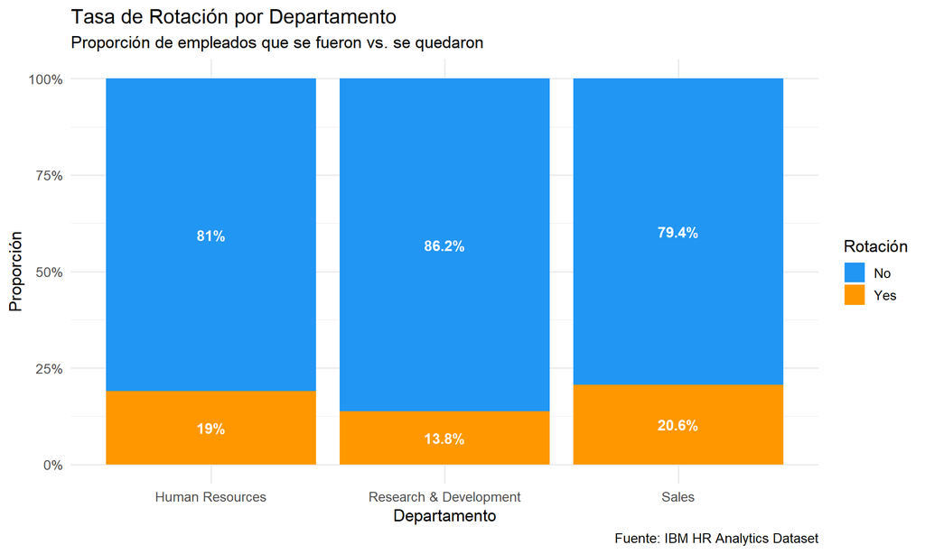

```r
# Gráfico de barras apiladas: Departamento vs Attrition
df %>%
  count(Department, Attrition) %>%
  group_by(Department) %>%
  mutate(porcentaje = n / sum(n) * 100) %>%
  ggplot(aes(x = Department, y = porcentaje, fill = Attrition)) +
  geom_col(position = "fill") +
  geom_text(aes(label = paste0(round(porcentaje, 1), "%")),
            position = position_fill(vjust = 0.5),
            color = "white", size = 4, fontface = "bold") +
  scale_y_continuous(labels = scales::percent) +
  scale_fill_manual(values = c("No" = "#2196F3", "Yes" = "#FF9800")) +
  theme_minimal(base_size = 13) +
  labs(
    title    = "Tasa de Rotación por Departamento",
    subtitle = "Proporción de empleados que se fueron vs. se quedaron",
    x        = "Departamento",
    y        = "Proporción",
    fill     = "Rotación",
    caption  = "Fuente: IBM HR Analytics Dataset"
  )
```

# 8. Matriz de correlaciones

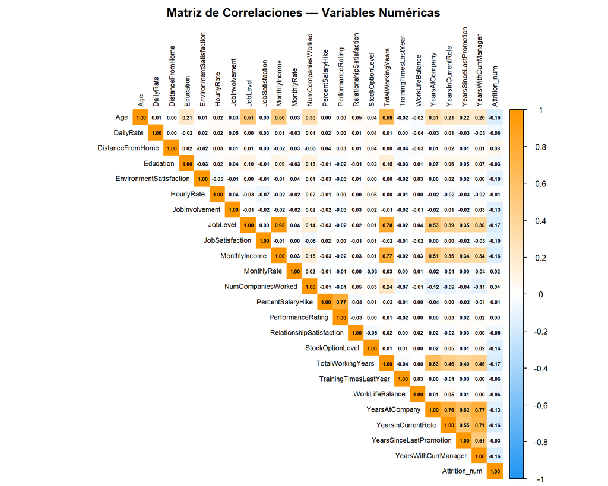

```r
# Seleccionar solo variables numéricas
vars_cor <- df %>%
  select(where(is.numeric)) %>%
  # Agregar Attrition como 0/1 para incluirla en la correlación
  bind_cols(Attrition_num = ifelse(df$Attrition == "Yes", 1, 0))

# Calcular matriz de correlación
matriz_cor <- cor(vars_cor, use = "complete.obs")

# Visualizar
corrplot(matriz_cor,
         method  = "color",
         type    = "upper",
         tl.cex  = 0.7,
         tl.col  = "black",
         addCoef.col = "black",
         number.cex  = 0.5,
         col     = colorRampPalette(c("#2196F3", "white", "#FF9800"))(200),
         title   = "Matriz de Correlaciones — Variables Numéricas",
         mar     = c(0, 0, 2, 0))
```

# 9. Conclusiones preliminares del EDA

```r
# Tasa general de rotación
tasa_rotacion <- mean(df$Attrition == "Yes") * 100

# Ingreso promedio por grupo
ingreso_promedio <- df %>%
  group_by(Attrition) %>%
  summarise(
    ingreso_medio  = round(mean(MonthlyIncome), 0),
    edad_media     = round(mean(Age), 1),
    anios_empresa  = round(mean(YearsAtCompany), 1)
  )

cat("=== HALLAZGOS PRELIMINARES ===\n\n")
```

```
## === HALLAZGOS PRELIMINARES ===
```

```r
cat("Tasa general de rotación:", round(tasa_rotacion, 1), "%\n\n")
```

```
## Tasa general de rotación: 16.1 %
```

```r
print(ingreso_promedio)
```

```
## # A tibble: 2 × 4
##   Attrition ingreso_medio edad_media anios_empresa
##   <chr>             <dbl>      <dbl>         <dbl>
## 1 No                 6833       37.6           7.4
## 2 Yes                4787       33.6           5.1
```

# Interpretación — Perfil de Empleado en Riesgo de Rotación

> **Nota metodológica:** Los hallazgos descritos a continuación corresponden a análisis descriptivo y exploratorio. Las asociaciones identificadas no implican causalidad — su confirmación estadística se desarrolla en el notebook 03 (modelo predictivo).

## Hallazgos cuantitativos base

| Variable | No rota | Sí rota | Diferencia |
| --- | --- | --- | --- |
| Ingreso mensual promedio | $6.833 | $4.787 | **-$2.046 (-30%)** |
| Edad promedio | 37.6 años | 33.6 años | **-4 años** |
| Antigüedad promedio | 7.4 años | 5.1 años | **-2.3 años** |

## Perfil 1 — Rotación temprana (años 1-3)

El segmento con mayor concentración de rotación corresponde a empleados jóvenes con menor compensación económica. La brecha salarial de un 30% respecto a quienes permanecen sugiere que la organización no logra sostener la percepción de equidad interna durante el período de integración inicial.

Este patrón es consistente con literatura organizacional sobre el **período de luna de miel** — una fase de alta motivación y expectativa que, de no ser reforzada con señales concretas de desarrollo y reconocimiento, tiende a erosionarse en los primeros 24-36 meses.

**Implicancia para intervención:** Extender y sostener activamente ese período mediante acompañamiento estructurado en los primeros dos años — onboarding prolongado, mentorías, revisiones salariales tempranas y planes de carrera visibles desde el ingreso.

## Perfil 2 — Rotación media (años 5-7)

La hipótesis más plausible es la presencia de **barreras de desarrollo profesional** — momentos donde el crecimiento se estanca, la compensación no avanza al ritmo esperado o las oportunidades de ascenso son percibidas como limitadas o inequitativas. En contextos de alta demanda laboral especializada — como la minería en la II Región — este perfil representa un riesgo especialmente crítico dado el costo de reposición.

## Síntesis ejecutiva

> El análisis sugiere que la rotación en esta organización no responde a un perfil único, sino a **dos momentos críticos diferenciados** en la trayectoria laboral: uno asociado a la consolidación del vínculo inicial y otro a barreras de desarrollo en la etapa intermedia. Ambos son prevenibles con intervenciones focalizadas y oportunas.

*Basado en análisis exploratorio del IBM HR Analytics Dataset*